# DataViz Makeover 1

Drag the ‘Country im yoyr’ from ‘Im_yoyr’ to color.

We can see the draft as figure below.

[figure not shown]

Then we start modify the graph. We edit the title and subtitle, edit the Y axis title, right click the X axis and select edit axis and delete the title in the newly appeared window.

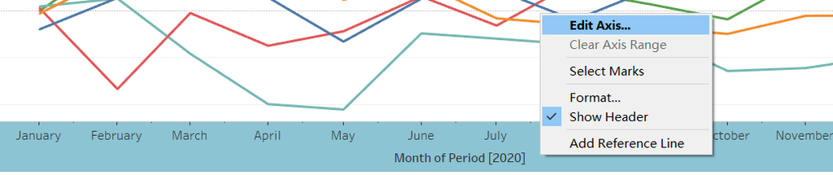

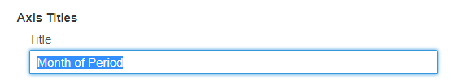

Then we edit the legend by right click every country label and select edit alias. We keep the country name only.

Finally add some annotates.The final ‘Year-on-year Ratio’ is as follow.

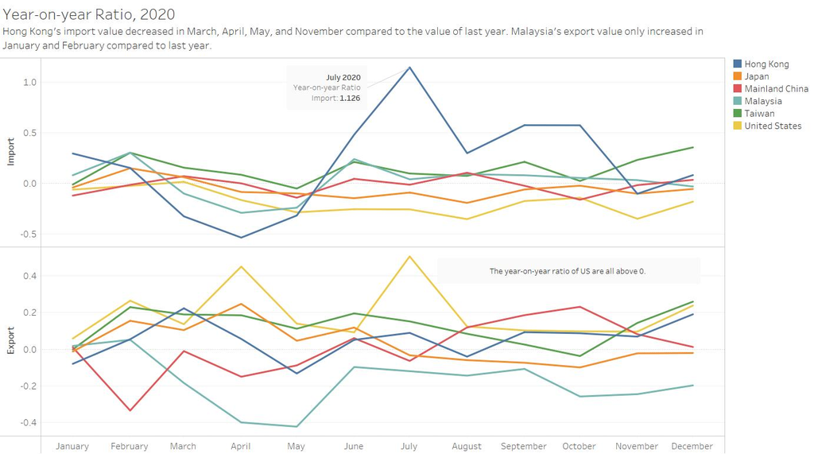

4. Create a dash board.

We drag the ‘Merchandise Trade’ and ‘Year-on-year Ratio’ to the dashboard and adjust them.

Then we check ‘show dashboard title’ and then edit it.

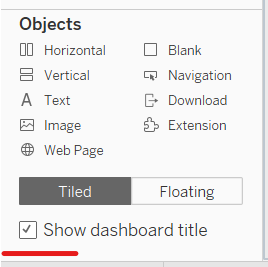

Right click the dashboard title area and select format title, select two different light gray for the dashboard background and title shading.

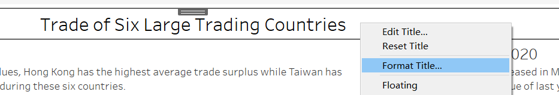

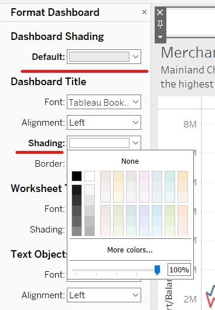

# 5.0 Observations